# Global warming through data - an artistic approach

Filippo Pilutti

2026-11-13

## Objective

Starting from the NASA [GISTEMP dataset](https://data.giss.nasa.gov/gistemp/data_v4.html), our goal is to artistically visualize the evolution of global temperatures over time. We aim to move beyond conventional data visualization techniques by creating a distinctive and visually compelling representation that combines artistic expression with statistical accuracy, while preserving the underlying data and its meaning.

## Importing and tidying the data

```r
url <- paste0(
  "https://data.giss.nasa.gov/gistemp/",
  "tabledata_v4/GLB.Ts+dSST.csv"
)

temp_raw <- read_csv(
  url,
  skip = 1,
  na = c("***", "****"),
  show_col_types = FALSE
)

glimpse(temp_raw)
```

```
## Rows: 147
## Columns: 19
## $ Year  <dbl> 1880, 1881, 1882, 1883, 1884, 1885, 1886, 1887, 1888, 1889, 1890…
## $ Jan   <dbl> -0.19, -0.20, 0.16, -0.29, -0.13, -0.58, -0.44, -0.72, -0.34, -0…
## $ Feb   <dbl> -0.25, -0.14, 0.13, -0.37, -0.08, -0.34, -0.51, -0.57, -0.36, 0.…
## $ Mar   <dbl> -0.09, 0.03, 0.04, -0.12, -0.36, -0.27, -0.43, -0.35, -0.42, 0.0…
## $ Apr   <dbl> -0.16, 0.05, -0.16, -0.18, -0.40, -0.42, -0.28, -0.35, -0.21, 0.…
## $ May   <dbl> -0.10, 0.06, -0.14, -0.18, -0.33, -0.45, -0.24, -0.30, -0.22, -0…
## $ Jun   <dbl> -0.21, -0.19, -0.22, -0.07, -0.35, -0.44, -0.35, -0.25, -0.17, -…
## $ Jul   <dbl> -0.19, 0.00, -0.16, -0.08, -0.30, -0.34, -0.18, -0.26, -0.11, -0…
## $ Aug   <dbl> -0.10, -0.03, -0.08, -0.14, -0.28, -0.31, -0.30, -0.35, -0.16, -…
## $ Sep   <dbl> -0.15, -0.15, -0.15, -0.22, -0.27, -0.28, -0.23, -0.25, -0.12, -…
## $ Oct   <dbl> -0.23, -0.22, -0.23, -0.11, -0.25, -0.23, -0.27, -0.35, 0.01, -0…
## $ Nov   <dbl> -0.22, -0.19, -0.17, -0.24, -0.33, -0.24, -0.28, -0.26, 0.02, -0…
## $ Dec   <dbl> -0.18, -0.07, -0.36, -0.11, -0.31, -0.10, -0.25, -0.33, -0.04, -…
## $ `J-D` <dbl> -0.17, -0.09, -0.11, -0.18, -0.28, -0.33, -0.31, -0.36, -0.18, -…
## $ `D-N` <dbl> NA, -0.10, -0.09, -0.20, -0.27, -0.35, -0.30, -0.35, -0.20, -0.0…
## $ DJF   <dbl> NA, -0.17, 0.07, -0.34, -0.11, -0.41, -0.35, -0.51, -0.35, 0.01,…
## $ MAM   <dbl> -0.12, 0.05, -0.09, -0.16, -0.36, -0.38, -0.32, -0.33, -0.28, 0.…
## $ JJA   <dbl> -0.17, -0.07, -0.16, -0.10, -0.31, -0.36, -0.28, -0.29, -0.14, -…
## $ SON   <dbl> -0.20, -0.18, -0.18, -0.19, -0.28, -0.25, -0.26, -0.29, -0.03, -…
```

```r
temp <- temp_raw |>
  select(Year, Jan:Dec) |>
  pivot_longer(
    cols = Jan:Dec,
    names_to = "month",
    values_to = "anomaly"
  ) |>
  mutate(
    month = factor(month, levels = month.abb),
    date = as.Date(
      paste(Year, month, "01", sep = "-"),
      format = "%Y-%b-%d"
    )
  ) |>
  drop_na(anomaly)

temp <- temp |>
  mutate(month = match(month, month.abb))

head(temp, n = 12)
```

```
## # A tibble: 12 × 4
##     Year month anomaly date
##    <dbl> <int>   <dbl> <date>
##  1  1880     1   -0.19 NA
##  2  1880     2   -0.25 1880-02-01
##  3  1880     3   -0.09 1880-03-01
##  4  1880     4   -0.16 1880-04-01
##  5  1880     5   -0.1  NA
##  6  1880     6   -0.21 NA
##  7  1880     7   -0.19 NA
##  8  1880     8   -0.1  NA
##  9  1880     9   -0.15 NA
## 10  1880    10   -0.23 NA
## 11  1880    11   -0.22 1880-11-01
## 12  1880    12   -0.18 NA
```

```r
glimpse(temp)
```

```
## Rows: 1,761
## Columns: 4
## $ Year    <dbl> 1880, 1880, 1880, 1880, 1880, 1880, 1880, 1880, 1880, 1880, 18…
## $ month   <int> 1, 2, 3, 4, 5, 6, 7, 8, 9, 10, 11, 12, 1, 2, 3, 4, 5, 6, 7, 8,…
## $ anomaly <dbl> -0.19, -0.25, -0.09, -0.16, -0.10, -0.21, -0.19, -0.10, -0.15,…
## $ date    <date> NA, 1880-02-01, 1880-03-01, 1880-04-01, NA, NA, NA, NA, NA, N…
```

## Artwork generation

```r
# number of points used to draw the curve of each blade
n_points <- 12

# define needed data, one blade of grass per monthly observation
grass <- temp |>
  mutate(
    blade_id = row_number(),
    # divide in rows, one per each decade, oldest on top
    decade = (Year %/% 10) * 10,
    row = (decade - min(decade)) / 10,
    # horizontal position within the decade (from 0 to 10 years)
    x_root = (Year - decade) + (month - 1) / 12,
    y_root = -row,

    # heat stress: 0 is coldest month on record, 1 warmest
    # stress = rescale(anomaly, to = c(0, 1)),

    # healthy blades are tall green and straight,
    # stressed blades are short red and bent
    # height = 1.1 - 0.85 * stress,
    # lean = 1.1 * stress

    # raw anomaly: 0 is the 1951-1980 average
    height = 0.8 - 0.35 * anomaly,
    lean = 0.7 * anomaly
  )

# bending of the blades
# t = 0 is the root, t = 1 is the tip
blades <- grass |>
  cross_join(tibble(t = seq(0, 1, length.out = n_points))) |>
  mutate(
    x = x_root + lean * t^2, # bends more towards the tip
    y = y_root + height * t, # grows steadily upwards
    width = 0.75 * (1 - 0.8 * t) # thick at the root, thin at the tip
  )

# labels for the decades
decade_labels <- grass |>
  distinct(decade, y_root)

# Legend: three sample blades drawn with the same rules
legend_y <- min(grass$y_root) - 1.9

legend_grass <- tibble(
  anomaly = c(-0.8, 0, 1.5),
  label = c(
    "-0.8 \u00B0C\ncolder than average:\ntall, green, leaning left",
    "0 \u00B0C\n1951-1980 average:\nupright",
    "+1.5 \u00B0C\nwarmer than average:\nshort, red, leaning right"
  ),
  blade_id = c(-1, -2, -3),
  x_root = c(2, 5, 8),
  y_root = legend_y
) |>
  mutate(
    # same mapping used for the real blades
    height = 0.8 - 0.35 * anomaly,
    lean = 0.7 * anomaly
  )

legend_blades <- legend_grass |>
  cross_join(tibble(t = seq(0, 1, length.out = n_points))) |>
  mutate(
    x = x_root + lean * t^2,
    y = y_root + height * t,
    # slightly thicker than real blades, to be readable
    width = 1.5 * (1 - 0.8 * t)
  )

# Artwork
artwork <- ggplot(blades) +
  geom_path(
    aes(
      x = x,
      y = y,
      group = blade_id,
      color = anomaly,
      linewidth = width
    ),
    lineend = "round"
  ) +
  geom_text(
    data = decade_labels,
    aes(x = -0.25,
        y = y_root + 0.12,
        label = decade),
    hjust = 1,
    size = 3,
    color = "grey45",
    family = "serif"
  ) +
  # legend blades
  geom_path(
    data = legend_blades,
    aes(
      x = x, y = y,
      group = blade_id,
      color = anomaly,
      linewidth = width
    ),
    lineend = "round"
  ) +
  # legend captions
  geom_text(
    data = legend_grass,
    aes(x = x_root, y = y_root - 0.2, label = label),
    vjust = 1,
    size = 2.8,
    lineheight = 0.95,
    color = "grey35",
    family = "serif"
  ) +
  scale_color_gradientn(
    colors = c(
      "#0B5D3B", "#3E9B4F", "#B7C65A",
      "#E0A93B", "#C4541F", "#7A1712"
    ),
    values = rescale(c(-0.8, -0.3, 0.1, 0.5, 0.95, 1.5)),
    limits = c(-0.85, 1.55),
    oob = squish,
    guide = "none"
  ) +
  scale_linewidth_identity() +
  scale_x_continuous(limits = c(-1, 11.2)) +
  scale_y_continuous(expand = expansion(add = c(1.3, 0.3))) +
  labs(
    title = "As the grass burns",
    subtitle = "Each blade of grass is one month of global temperature, 1880 to today"
  ) +
  theme_void(base_family = "serif") +
  theme(
    plot.background = element_rect(fill = "#F6F1E7", color = NA),
    plot.title = element_text(
      size = 24, face = "bold", hjust = 0.5,
      margin = margin(t = 14, b = 4)
    ),
    plot.subtitle = element_text(
      size = 11, hjust = 0.5, color = "grey35",
      margin = margin(b = 10)
    ),
    plot.margin = margin(10, 20, 10, 20)
  )
```

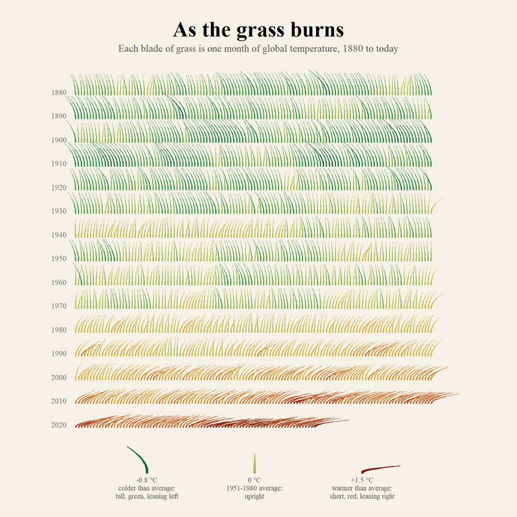

```r
artwork
```

The idea behind the artwork is to visualize the change of temperature through the years as a field of grass. Each blade of grass represents a month of the dataset, and its color, length and curve represent the anomaly of that month.

The grass field is read like a page of text: each row is a decade, from the 1880s at the top to the 2020s at the bottom, and within a row the blades follow one another month by month from left to right. All three visual properties of a blade are computed directly from the raw anomaly of its month, so that zero corresponds to the 1951–1980 average. The height decreases linearly with the anomaly (`height = 0.8 - 0.35 * anomaly`), so colder months grow taller and warmer months stay shorter. The sideways displacement of the tip is proportional to the anomaly (`lean = 0.7 * anomaly`): a month at the baseline stands upright, a colder month leans to the left and a warmer month leans to the right. The color follows a gradient from dark green for the coldest months, through yellow around the baseline, to dark red for the warmest ones.

To draw a curved blade instead of a straight segment, each observation is expanded into 12 points along a parameter `t` that goes from 0 at the root to 1 at the tip. The vertical position grows steadily with `t`, while the horizontal displacement grows with `t^2`, so the blade starts almost vertical and bends progressively towards the tip, tracing an arc of parabola. The points of each blade are connected with `geom_path()`, and the line width decreases from root to tip to give the blade a tapered shape. The three blades below the grass field act as a legend: they are generated with the same formulas, using the coldest anomaly on record, the baseline and the warmest anomaly on record.

The result is a field that is tall, green and leaning one way at the top, and gradually turns short, red and flattened in the opposite direction at the bottom: the warming trend is visible as the grass withers decade after decade.